# 7016 Project

Christopher Malone

30/10/2020

# Structure

Introduction - Motivation - State the dataset (including source) - Main issues - Who cares?

Methodology - Variables used - State and justify prior(s) - State and justify model(s) - Define all notation. State all assumptions. - Discuss the MCMC - Sequence of draws - Number of iterations - Burn-in period - Thinning interval - Proposal distribution - Did you use your own code? What did you use? * If you are using techniques we learned in class, you do not need to re-explain the theory behind the techniques. If you are using techniques that we did not cover in class, the techniques should be clearly explained in your report.

Results - Describe main findings - Relate the discussion to the original research question - Include graphs of results if appropriate - Show (a) model checking and (b) MCMC convergence diagnostics

Conclusions

Appendix - Provide a code appendix - Be selective with the output, to help clarity

Length: 15 pages max (including graphs, excluding appendices)

# Introduction

### The dataset

The dataset is comprised of two components, namely “supply” and “demand”. The “supply” dataset contains information on water prices, volume of water allocations supplied. Importantly, while “demand” information is provided for all MDB regions with relative consistency, “supply” information is provided for only roughly half of the regions for which there exist significant catchments along the basin. In particular, supply information is not provided for any region north of the Queensland border. As such, this analysis is restricted to a subset of regions

What we have, then, is “short” panel (or longitudinal) data. Panel data is data comprised of a cross section of the population, with measurements taken at varaious time points. We denote the number of observations $n = N \times T$, where $N$ is the number of individuals, and $T$ is the number of time points. We say that the panel is “balanced” when we have the same number of time intervals for each of the $N$ individuals.

In this dataset, we have a collection of time series, each with length $T = 13$. Each series is associated with a crop type and a geographic region (regions in turn correspond to “catchments”, i.e. areas where water collects naturally). It makes sense then to think of the panels (i.e. individuals) in our data as being crop-region pairs. For example, “almond farmers in NSW, South of the Murray Darling river” is one panel; “fruit farmers in NSW, North of the Murray Darling river” is another.

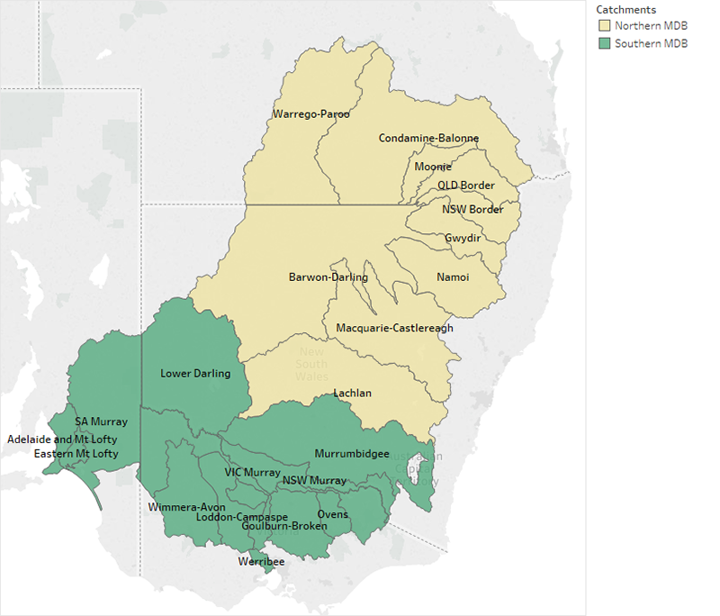

```r
knitr::include_graphics('img/mdb-map-low-res.png')
```

In the dataset, there are observations that fall outside of the period I consider, for some regions. However, I ignore these, for the convenience of working with a “balanced” panel (equal time periods for all individuals).

# Methodology

### The model

To explore the question discussed above, I have chosen to employ a Bayesian normal linear regression model.

### Variables

My variable choices have largely been led by a priori considerations, and checked with prior modelling using maximum likelihood parameter estimation. Each variable I have employed in the final Bayesian model was highly significant in all models checked before beginning the Bayesian analysis.

Under ideal conditions, to determine the answer to our question, we would use measures of efficiency improvement, and quantify their relation ship to changes in volume applied. However, information is not availabel on efficiency improvement. Instead then, I treat a closely related question. This is to find the relationship between the price of water and the volume applied.

The response variable I am working with is the log of the volume of water applied. I have chosen to log transform this variable as I found in prior modelling that it improved the quality of fit for all models. A priori, it is not surprising that this would be the case, as volume is strictly positive, and likely to be right skewed.

The key predictor variable is `price`. I include this variable as the goal of the study is to understand the relationship between price and volume of water applied.

I include the important confounding variable `rainfall`. A priori, we can expect rainfall to be negatively correlated with both water price and volume applied. When rainfall is high for a given year, a number of important changes occur. Firstly, farmers do not need to apply as much irrigated water as they would, if rainfall were low. So rainfall decreases volume applied directly. Secondly, when rainfall is high, catchment water levels rise, increasing the supply of water, which negatively affects the price.

It is difficult to know whether or not to estimate main effects for crop type or region. Common sense, and some prior experience with the data, indicates that there are strong significant effects for crop type and region. However, I do not include these in the model, as they are not relevant to the question at hand.

Another interesting avenue would be to employ a hierarchical modelling strategy for the coefficients. This is because the fixed effects assumption does not hold here. We are sampling from a subset of the population. However, hierarchical modelling is most beneficial when panels are unbalanced – i.e. when we have more information about some groups than others.

### Time dependence of errors (serial correlation)

Preliminary modelling led me to believe that there was a significant portion of time dependence in the residuals. To control for this, I have employed Hoff’s regression model with AR(1) variance-covariance structure, and “Bayesian GLS” parameter estimation. I have adapted Hoff’s estimation technique and model structure to deal with panel data.

Panel data is unlike ordinary time series, in that we are dealing with many time series simultaneously. To adapt Hoff’s technique, I have assumed that observations between time-steps are correlated within panels, but not between.

To see what I mean, consider an example where we have panel data where $T = 3$ and $N = 2$, and AR(1) autoregressive covariance structure. Then, where $\sigma^2$ is the conditional variance of $(y|X)$, and $\rho$ is the coefficient of correlation, the observations have the following covariance structure. Note that the structure is such that it is an $NT \times NT$ matrix with two identical $T \times T$ sub-matrices “down its diagonal”.
$$\Sigma = \sigma^2
\begin{pmatrix}
1 & \rho & \rho^2 & 0 & 0 & 0 \\
\rho & 1 & \rho & 0 & 0 & 0 \\
\rho^2 & \rho & 1 & 0 & 0 & 0 \\
0 & 0 & 0 & 1 & \rho & \rho^2\\
0 & 0 & 0 & \rho & 1 & \rho \\
0 & 0 & 0 & \rho^2 & \rho & 1
\end{pmatrix}$$

Note that each observation from the first panel is assumed independent of any observations in the second panel. On the other hand, *within* a given panel, observations are correlated, with correlation coefficient $\rho$ describing the dependence relationship.

As the reader will recall, the present panel has $N = 94$, $T = 13$, and $n = NT = 1222$. So the covariance matrix is an $n \times n = 1222 \times 1222$ matrix, which has $N = 94$ matrices of size $T \times T = 13 \times 13$ “down its diagonal”, and zeroes elsewhere.